# Inferring Microbial Networks in Different Soil Conditions

Dexter Chen

14/10/2024

## Preprocessing

The raw dataset from **n_starvation.rds** consists of three subsets: **otu_table**, **tax_table** and **sam_data**. Split by nitro condition by **growthCondition**.

```r
library(phyloseq)
library(SPRING)
library(SpiecEasi)
library(JGL)
library(EstimateGroupNetwork)
library(SpiecEasi)
library(igraph)
library(caret)     # For confusionMatrix function
library(pROC)      # For ROC and AUC calculation
library(MLmetrics) # For F1 Score, MCC
library(ggplot2)
library(tidyr)
library(ggraph)
library(tidyverse)
library(RColorBrewer)
library(dplyr)
rawdata <- readRDS("data//n_starvation.rds")
otu_Ab <- as.data.frame(t(otu_table(rawdata)))
sam_info <- as.data.frame(sample_data(rawdata))
otu_tax <- as.data.frame(tax_table(rawdata))
shared_otu <- colnames(otu_Ab)
# split otu_Ab by meta
otu_Ab_Nplus <- otu_Ab[rownames(otu_Ab) %in% rownames(sam_info[sam_info$growthCondition=="plusN",]),]
otu_Ab_Nminus <- otu_Ab[rownames(otu_Ab) %in% rownames(sam_info[sam_info$growthCondition=="minusN",]),]

# %%
preprocess_and_estimate_network <- function(data_list, labels = NULL,  nlambda1 = 30, nlambda2 = 30)
  {
    # Helper function for common scaling normalization
    norm_to_total <- function(x) x / sum(x)
    common_scaling <- function(data) {
      depths <- rowSums(data)
      data_normalized <- t(apply(data, 1, norm_to_total))
      common_depth <- min(depths)  # Calculate only once
      data_common_scaled <- round(data_normalized * common_depth)
      return(data_common_scaled)
    }
    # Preprocessing steps for each data set in the list
    processed_data_list <- lapply(data_list, function(data) {
      scaled_data <- common_scaling(data)
      mclr_data <- mclr(scaled_data) # Using SPRING's mclr
      Kcor <- mixedCCA::estimateR(mclr_data, type = "trunc", method = "approx", tol = 1e-6, verbose = FALSE)$R
      return(Kcor)
    })

    # Sample sizes for each dataset.
    n_samples <- sapply(data_list, nrow)

    # Estimate the network using the preprocessed data
    Res <- EstimateGroupNetwork(
      processed_data_list,
      inputType = "list.of.covariance.matrices",
      n = n_samples,
      labels = labels, # Pass labels directly
      nlambda1 = nlambda1,
      nlambda2 = nlambda2,
      truncate = 1e-10,
      criterion = 'bic'
    )
    return(Res)
  }
data_list <- list(Nplus = otu_Ab_Nplus, Nminus = otu_Ab_Nminus)
network_results <- preprocess_and_estimate_network(data_list, labels = shared_otu)
network_Nplus <- network_results$Nplus
network_Nminus <- network_results$Nminus
head(otu_Ab_Nplus,n = c(5,5))
```

```
##          OTU_0000044 OTU_0000076 OTU_0000126 OTU_0000017 OTU_0000342
## X4SNR1             0           0           0           0           0
## X4SNH2            14          70           0           0          11
## X12RWNH4         733          35           7         102          10
## X8GSNR1           22           2           0          62          52
## X16GSNH4           9          11           0          50           6
```

```r
head(otu_Ab_Nminus,n = c(5,5))
```

```
##          OTU_0000044 OTU_0000076 OTU_0000126 OTU_0000017 OTU_0000342
## X4RW.NR4           8           4          10           5           0
## X4S.NH1           48         288         231           0           0
## X16S.NH1         109           0          57           0           6
## X4GS.NH3         265          53         259         331           0
## X4RW.NH5         295         157         369          48           0
```

## Synthesize simulated networks

### Normalization and scaling

Now, normalize and scale the aboundance data by default. Firstly, calculate the sum of each row (representing the sequencing depth for each sample) and finds the minimum depth across all samples. Then, normalize each row to sum to 1 and multiply the normalized values by the minimum depth. Finally, round the scaled values to integers. This method aims to adjust the data to a common scale while preserving the relative abundance of features within each sample.

### mClr and correlation matrix

The second part of the function performs modifed centre logratio using **SPRING** and estimate the correlation matrix using **mixedCCA**.

Finally, apply joint graphical lasso and generate the true nerwork using the **EstimateGroupNetwork**

```r
preprocess_and_estimate_network <- function(data_list, labels = NULL,  nlambda1 = 10, nlambda2 = 10)
  {
    # Helper function for common scaling normalization
    norm_to_total <- function(x) x / sum(x)
    common_scaling <- function(data) {
      depths <- rowSums(data)
      data_normalized <- t(apply(data, 1, norm_to_total))
      common_depth <- min(depths)  # Calculate only once
      data_common_scaled <- round(data_normalized * common_depth)
      return(data_common_scaled)
    }
    # Preprocessing steps for each data set in the list
    processed_data_list <- lapply(data_list, function(data) {
      scaled_data <- common_scaling(data)
      mclr_data <- mclr(scaled_data) # Using SPRING's mclr
      Kcor <- mixedCCA::estimateR(mclr_data, type = "trunc", method = "approx", tol = 1e-6, verbose = FALSE)$R
      return(Kcor)
    })

    # Sample sizes for each dataset.
    n_samples <- sapply(data_list, nrow)

    # Estimate the network using the preprocessed data
    Res <- EstimateGroupNetwork(
      processed_data_list,
      inputType = "list.of.covariance.matrices",
      n = n_samples,
      labels = labels, # Pass labels directly
      nlambda1 = nlambda1,
      nlambda2 = nlambda2,
      truncate = 1e-10,
      criterion = 'bic'
    )

    return(Res)
  }
data_list <- list(Nplus = otu_Ab_Nplus, Nminus = otu_Ab_Nminus)
network_results <- preprocess_and_estimate_network(data_list, labels = shared_otu)
network_Nplus <- network_results$Nplus
network_Nminus <- network_results$Nminus
head(network_Nplus,n = c(5,5))
```

```
##             OTU_0000044 OTU_0000076 OTU_0000126 OTU_0000017 OTU_0000342
## OTU_0000044  0.00000000  0.00000000  0.00000000  0.06054722  0.00000000
## OTU_0000076  0.00000000  0.00000000  0.01554315  0.00000000  0.00000000
## OTU_0000126  0.00000000  0.01554315  0.00000000  0.00000000  0.00000000
## OTU_0000017  0.06054722  0.00000000  0.00000000  0.00000000  0.05882131
## OTU_0000342  0.00000000  0.00000000  0.00000000  0.05882131  0.00000000
```

```r
head(network_Nminus,n = c(5,5))
```

```
##             OTU_0000044 OTU_0000076 OTU_0000126 OTU_0000017 OTU_0000342
## OTU_0000044  0.00000000  0.08050093  0.00000000  0.05903023  0.00000000
## OTU_0000076  0.08050093  0.00000000  0.06504706  0.00000000  0.00000000
## OTU_0000126  0.00000000  0.06504706  0.00000000  0.03072217  0.00000000
## OTU_0000017  0.05903023  0.00000000  0.03072217  0.00000000  0.09165632
## OTU_0000342  0.00000000  0.00000000  0.00000000  0.09165632  0.00000000
```

## Visualize on the network

### Edge weights distribution

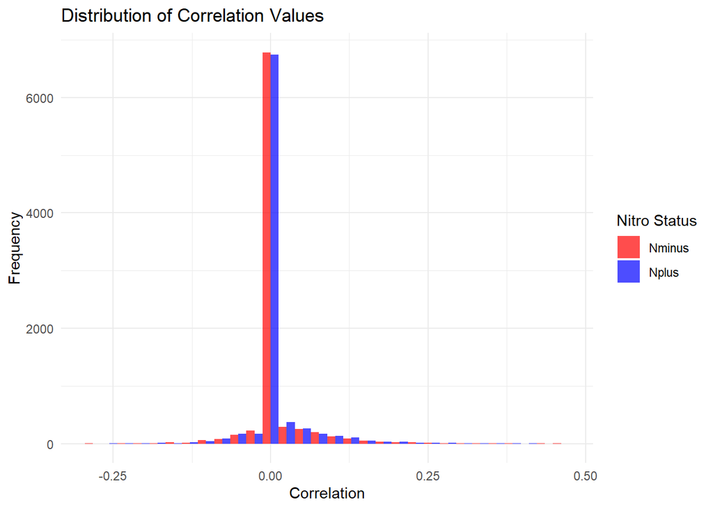

```r
cor_values_Nplus <- as.vector(network_Nplus)
cor_values_Nminus <- as.vector(network_Nminus)
cor_df <- data.frame(
  correlation = c(cor_values_Nplus, cor_values_Nminus),
  group = factor(rep(c("Nplus", "Nminus"), each = length(cor_values_Nplus)))
)
hist_plot <- ggplot(cor_df, aes(x = correlation, fill = group)) +
  geom_histogram(position = "dodge", bins = 30, alpha = 0.7) +
  scale_fill_manual(values = c("Nplus" = "blue", "Nminus" = "red")) +
  theme_minimal() +
  labs(title = "Distribution of Correlation Values",
       x = "Correlation",
       y = "Frequency",
       fill = "Nitro Status")
print(hist_plot)
```

### Plot network

Visualize the edge network seperately and colorized by Phylum.

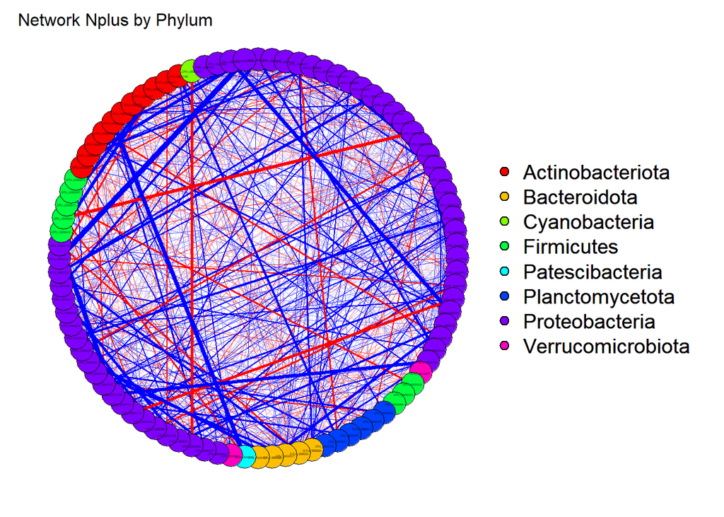

```r
Phylum_groups <- as.factor(otu_tax[rownames(network_Nplus),"Phylum"])
qgraph::qgraph(network_Nplus,
  layout = "circle",
  edge.color = ifelse(network_Nplus > 0, "blue", "red"),
  title = "Network Nplus by Phylum",
  groups = Phylum_groups)
```

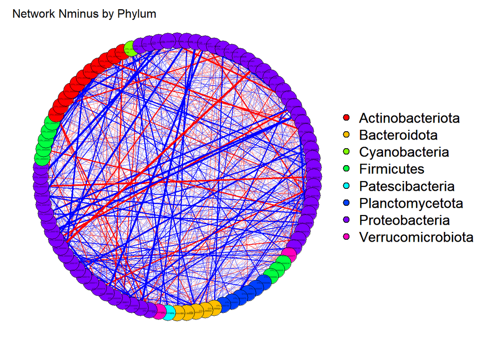

```r
qgraph::qgraph(network_Nminus,
  layout = "circle",
  edge.color = ifelse(network_Nminus > 0, "blue", "red"),
  title = "Network Nminus by Phylum",
  groups = Phylum_groups)
```

## Evaluate synthesized dataset

Now, synthesize 50 dataset based on the origin/true aboundance data.

```r
true_adj_Nplus <- (network_Nplus !=0)*1
true_adj_Nminus <- (network_Nminus !=0)*1
set.seed(10010)
synthesize_scaled_data <- function(dat, net)
  {
    graph <- (net != 0)*1     # SpiecEasi::make_graph('cluster', dat$n_OTUs, dat$n_edge)
    attr(graph, "class") <- "graph"
    Prec <- SpiecEasi::graph2prec(graph)
    Cor <- cov2cor(SpiecEasi::prec2cov(Prec))
    X <- SpiecEasi::synth_comm_from_counts(dat, mar = 2, distr = 'zinegbin', Sigma = Cor, n = nrow(dat))
    return(X)
  }
Sim_list <- list()
for (i in 1:50)
  {
    Sim_list[[i]] <- list(
      Nplus = synthesize_scaled_data(otu_Ab_Nplus, network_Nplus),
      Nminus = synthesize_scaled_data(otu_Ab_Nminus, network_Nminus)
    )
  }
Res_sim <- list()
for (i in 1:50)
  {
    Res_sim[[i]] <- preprocess_and_estimate_network(Sim_list[[i]], labels = shared_otu)
  }
Sim_adj <- list()
for (i in 1:50)
  {
    Sim_adj[[i]] <- list(
      Nplus = (Res_sim[[i]]$Nplus !=0)*1,
      Nminus = (Res_sim[[i]]$Nminus !=0)*1
    )
  }
calculate_mcc <- function(tp, tn, fp, fn)
  {
    numerator <- (tp * tn) - (fp * fn)
    denominator <- sqrt((tp + fp) * (tp + fn) * (tn + fp) * (tn + fn))

    # If the denominator is 0, return 0 to avoid NaN errors
    if (denominator == 0) {
      return(0)
    } else {
      return(numerator / denominator)
    }
  }
calculate_metrics <- function(true_adj, sim_adj)
  {
    # Flatten the matrices into vectors (upper triangular part, excluding diagonal)
    true_edges <- as.vector(true_adj[upper.tri(true_adj)])
    sim_edges <- as.vector(sim_adj[upper.tri(sim_adj)])

    # Confusion matrix
    cm <- confusionMatrix(as.factor(sim_edges), as.factor(true_edges), positive = "1")
    tn <- as.numeric(cm$table[1,1]) #true negatives
    fp <- as.numeric(cm$table[1,2]) #false positives
    fn <- as.numeric(cm$table[2,1]) #false negatives
    tp <- as.numeric(cm$table[2,2]) #true positives

    # Calculate TPR, FPR, Precision, Recall
    tpr <- tp / (tp + fn)  # Sensitivity / Recall
    fpr <- fp / (fp + tn)  # 1 - Specificity
    precision <- tp / (tp + fp)
    recall <- tpr

    # Calculate ROC and AUC
    roc_obj <- roc(true_edges, sim_edges)
    auc <- as.numeric(auc(roc_obj)) # plot here

    # F1 Score
    f1 <- F1_Score(sim_edges, true_edges)

    # MCC (Matthews correlation coefficient)
    mcc <- calculate_mcc(tp, tn, fp, fn)

    # Return metrics as a list
    return(list(TPR = tpr, FPR = fpr, Precision = precision, Recall = recall,
                F1 = f1, AUC = auc, MCC = mcc))
  }
confusion_results <- lapply(1:50, function(i)
    {
    Nplus_metrics <- calculate_metrics(true_adj_Nplus, Sim_adj[[i]]$Nplus)
    Nminus_metrics <- calculate_metrics(true_adj_Nminus, Sim_adj[[i]]$Nminus)
    # Return both results as a named list
    return(list(Nplus = Nplus_metrics, Nminus = Nminus_metrics))
    } )
results_df <- do.call(rbind, lapply(confusion_results, as.data.frame))
head(results_df,n = c(5,5))
```

```
##   Nplus.TPR Nplus.FPR Nplus.Precision Nplus.Recall  Nplus.F1
## 1       NaN 0.2453416     0.000000000          NaN 0.8601770
## 2 0.8400000 0.2417688     0.020447907    0.8400000 0.8620219
## 3 1.0000000 0.2444391     0.004868549    1.0000000 0.8607629
## 4 0.9411765 0.2425042     0.015579357    0.9411765 0.8618996
## 5 0.8571429 0.2422569     0.017526777    0.8571429 0.8618241
```

## Plot barplots to see the simulated matrices

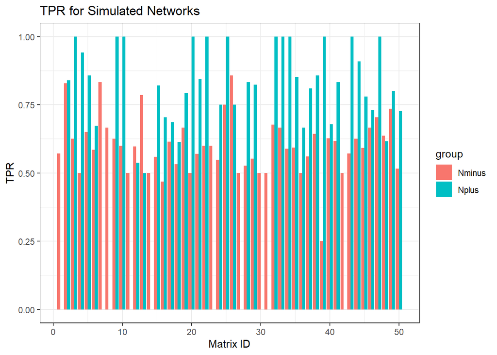

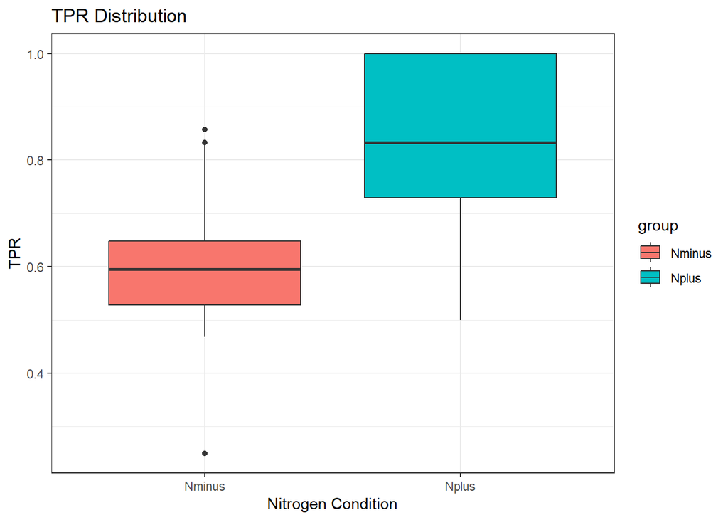

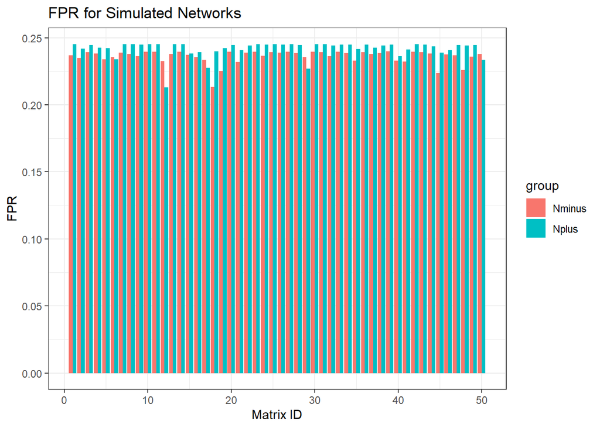

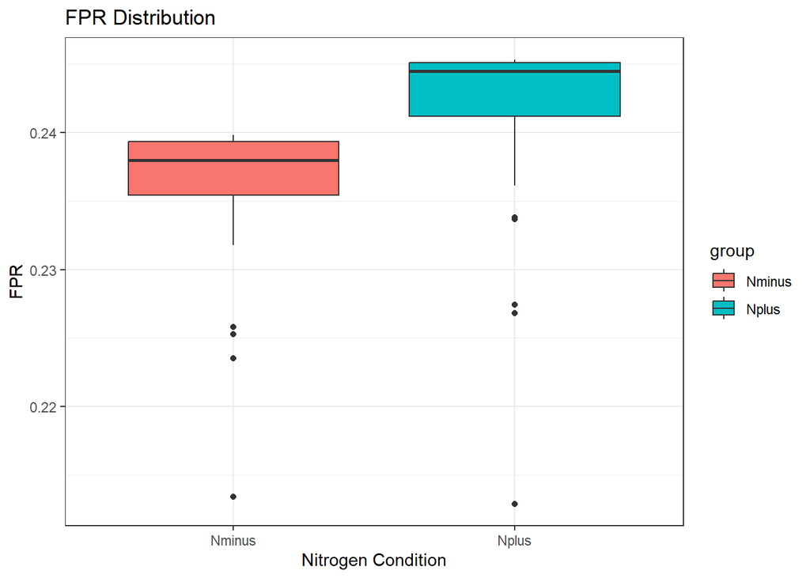

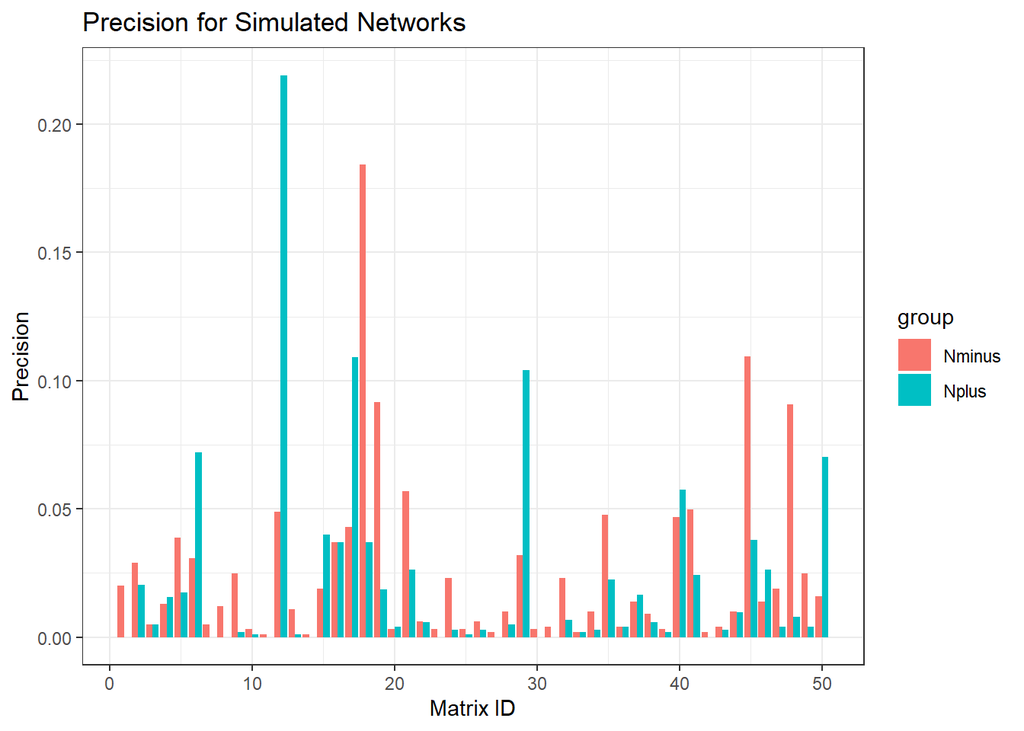

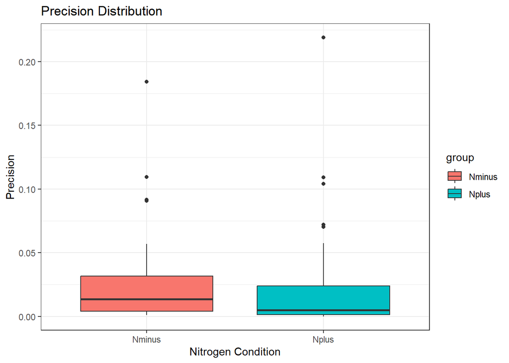

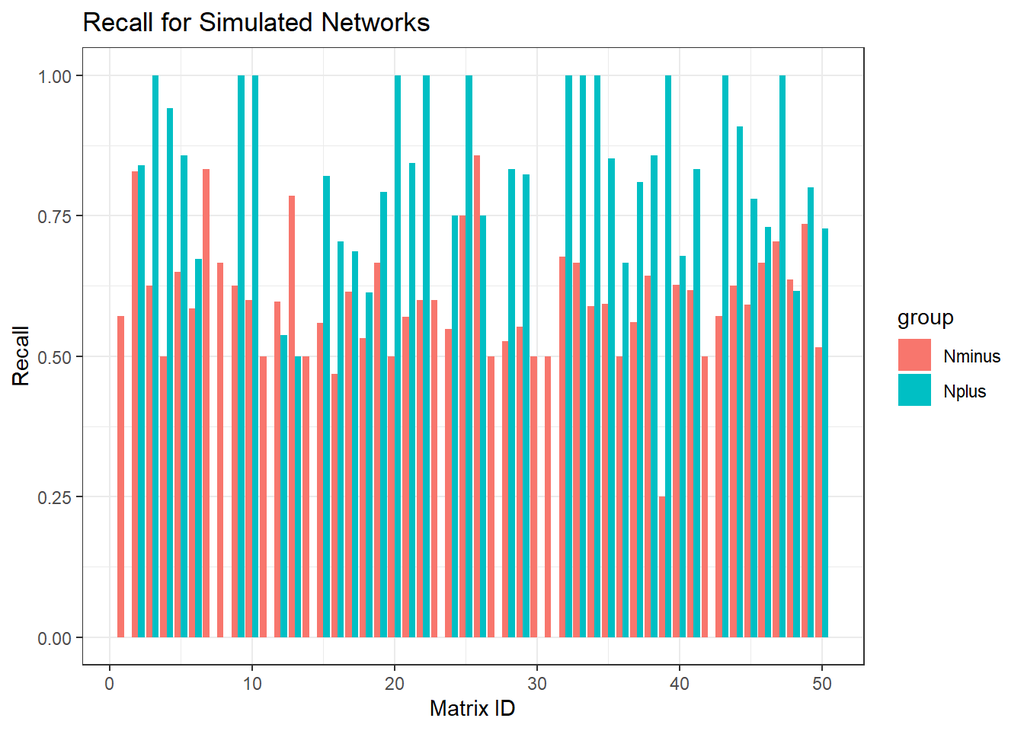

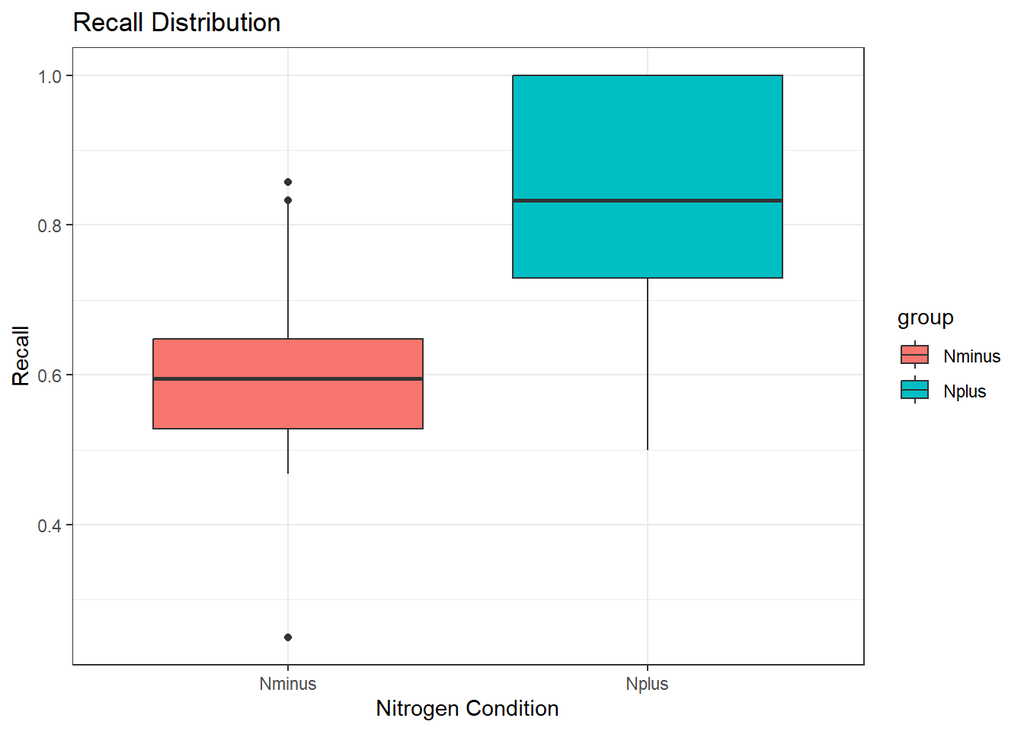

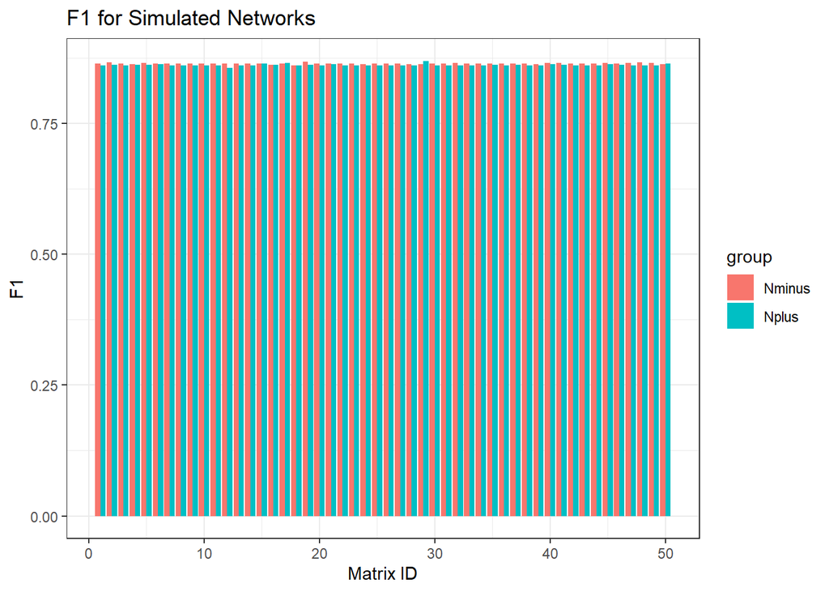

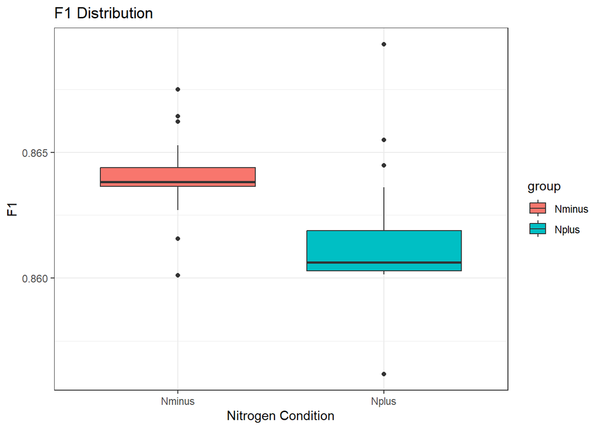

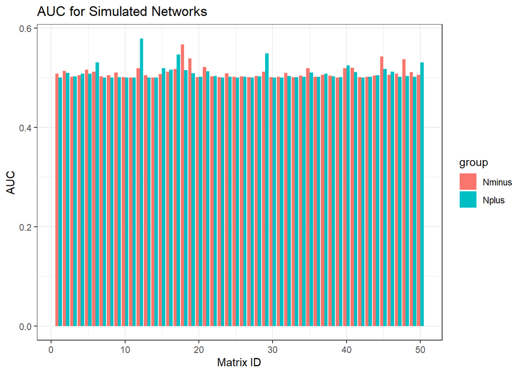

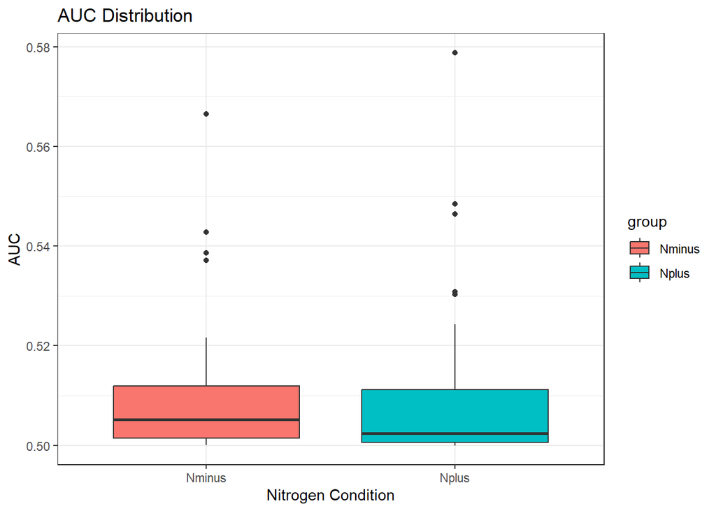

[2 more figures not shown]

```r
results_df_long <- results_df %>%
  dplyr::select(starts_with("Nplus.") | starts_with("Nminus.")) %>%
  tidyr::pivot_longer(cols = everything(),
               names_to = c("group", "metric"),
               names_sep = "\\.",
               values_to = "value") %>%
  dplyr::mutate(matrix_id = rep(1:50, each = 14))

for (metric_name in unique(results_df_long$metric)) {
    plot_data <- results_df_long %>%
        dplyr::filter(metric == metric_name)

    p1 <- ggplot(plot_data, aes(x = matrix_id, y = value, fill = group)) +
        geom_bar(stat = "identity", position = "dodge") +
        labs(title = paste(metric_name, "for Simulated Networks"),
            x = "Matrix ID",
            y = metric_name) +
        theme_bw()
    print(p1)
    p2 <- ggplot(plot_data, aes(x = group, y = value, fill = group)) +
        geom_boxplot() +
        labs(title = paste(metric_name, "Distribution"),
            x = "Nitrogen Condition",
            y = metric_name) +
        theme_bw()
    print(p2)
}
```